# gap_and_gas_study slides

## Analysis of MM-L300A Laser Weld Data

### Stainless steel lap welds

#### Prediction of gap and detection of presence or absence of cover gas

Several laser welding experiments were conducted at Amada Miyachi September 19, 2017. Two of these experiments studied the effects of gap between stainless steel (alloy 304) weldment pieces and presence or absence of cover gas (Nitrogen). These experiments are labeled "SS_0_300_N2" and "SS_0_300_NoGas", respectively. The gap distances in the samples range from 0 to 300 microns, as the experiment names imply, and were inferred from post-weld measurements as shown in this figure.

A third experiment, "SS_100", was run with either 100 micron gap or something. An infrared sensor with focusing optics measured relative optical power of infrared emissions in the 1300-2200nm band resulting from each laser spot weld event. The sensor and optics were collinear with the incident laser beam andd focused on the surface of the weldment.

The data from all three experiement are combined in a single DataFrame. Actual gap were inferred from the correlation between distance from edge of the material, assuming linear variation in gap from one end to the other as shown in this figure:

[figure not shown]

Fetch all data and load up a DataFrame

```
dbName = "mml300a"
collectionName = "y20170919"
df = db2pandas.createDF(db2pandas.openDB(dbName,collectionName))
```

```python
# get data from all set
dbName = "mml300a"
collectionName = "y20170919"
df = db2pandas.createDF(db2pandas.openDB(dbName,collectionName))
```

Get the data from the 'Variable gap' and 'no gap' experiments, with or without cover gas.

```
n2 = df["Experiment"] == "SS_0_300_N2"
ng = df["Experiment"] == "SS_0_300_NoGas"
nogap = df["Experiment"] == "SS_100"
dataWithGap = df.loc[n2|ng,["Experiment","Integrate","waveforms","Value"]]
```

```
dataWithGap = pd.get_dummies(dataWithGap, columns=["Experiment"], drop_first=True)
dataWithGap = dataWithGap.rename(index=int, columns={"Experiment_SS_0_300_NoGas":"Gas", "Value":"Gap"})
dataWithGap.columns
```

```python
dataWithGap = pd.get_dummies(dataWithGap, columns=["Experiment"], drop_first=True)
dataWithGap = dataWithGap.rename(index=int, columns={"Experiment_SS_0_300_NoGas":"Gas", "Value":"Gap"})
```

Get the 'No gap' data and process in a similar manner.

```
nogap = df["Experiment"] == "SS_100"
dataWithNoGap = df.loc[nogap,["Integrate","waveforms","Value"]]
dataWithNoGap = pd.get_dummies(dataWithNoGap, columns=["Value"], drop_first=True)
dataWithNoGap = dataWithNoGap.rename(index=int, columns={"Value_No Gas":"Gas"})
```

```python
dataWithNoGap = df.loc[nogap,["Integrate","waveforms","Value"]]
dataWithNoGap = pd.get_dummies(dataWithNoGap, columns=["Value"], drop_first=True)
dataWithNoGap = dataWithNoGap.rename(index=int, columns={"Value_No Gas":"Gas"})
```

Add a "Gap" column and load with zeros.

```
dataWithNoGap["Gap"] = 0
```

```python
dataWithNoGap["Gap"] = 0
data = dataWithGap.append(dataWithNoGap, ignore_index=True)
```

Combine the two DataFrames into the final tidy data set.

```
data = dataWithGap.append(dataWithNoGap, ignore_index=True)
```

A sample of the data set is shown here:

```python
data.sample(n=10)
```

|  | Gap | Gas | Integrate | waveforms |
| --- | --- | --- | --- | --- |
| 119 | 0 | 0 | 29781679 | [71, 94, 70, 92, 70, 107, 82, 134, 112, 131, 1... |
| 47 | 51 | 0 | 41511908 | [117, 91, 86, 97, 112, 117, 107, 79, 122, 103,... |
| 12 | 77 | 0 | 39621726 | [84, 131, 144, 144, 153, 136, 137, 148, 131, 1... |
| 60 | 120 | 1 | 61447353 | [1323, 6127, 12614, 16498, 18457, 21083, 23946... |
| 102 | 0 | 1 | 41133962 | [86, 96, 95, 92, 124, 140, 116, 126, 137, 133,... |
| 36 | 21 | 0 | 43278890 | [79, 97, 80, 83, 86, 90, 97, 67, 116, 115, 120... |
| 1 | 252 | 0 | 32936363 | [85, 102, 74, 96, 121, 419, 3317, 9390, 14518,... |
| 48 | 29 | 0 | 42887908 | [120, 105, 124, 131, 108, 168, 138, 134, 159, ... |
| 28 | 228 | 0 | 29359541 | [94, 122, 136, 149, 102, 136, 216, 1996, 7088,... |
| 64 | 30 | 1 | 56847273 | [131, 154, 135, 150, 214, 1995, 7427, 13152, 1... |

Now we extract features from the waveform data.

First, automatically determine reasonable intervals of interest from the waveform data. To do this, we average all the waveforms, apply a piecewise linear fitter using an mathematical optimizer to set the begin and end points of the intervals. We can choose the maximum number of intervals to generate, and also we can choose a threshold value to eliminate intervals shorter than a prescribed length. These numbers can be used to tune the model, minimize over-fitting, and improve generalization.

```
meanWaveform = np.array(list(data["waveforms"]))
meanWaveform = sum(meanWaveform)/len(meanWaveform)

im2 = intervalmaker.IntervalMaker(meanWaveform, 4, 200, **filt_params)
res = im2.pieceWiseLinear(**opt_params)
```

```python
meanWaveform = np.array(list(data["waveforms"]))
meanWaveform = sum(meanWaveform)/len(meanWaveform)
```

```python
im2 = intervalmaker.IntervalMaker(meanWaveform, 4, 200, **filt_params)
res = im2.pieceWiseLinear(**opt_params)
```

```
     fun: 14345049609.321445
 message: 'Optimization terminated successfully.'
    nfev: 384
     nit: 1
 success: True
       x: array([ 1736.09121688,   737.4412247 ,   723.37532732])
```

Get the filtered optimized time intervals of interest, along with the x and y data and optimized breakpoints.

Plot the results.

```
x = im2.x
y = im2.y
y_detrend = im2.train_detrended
b_points = im2.bp
intervals = im2.final_intervals
```

```python
x = im2.x
y = im2.y
y_detrend = im2.train_detrended
b_points = im2.bp
intervals = im2.final_intervals
```

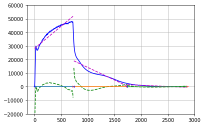

```python
plt.plot(x,meanWaveform, 'b-')

for i in intervals:
    plt.plot(np.arange(*i), (y-y_detrend[1])[np.arange(*i)], 'm--')
    plt.plot(np.arange(*i), y_detrend[1][np.arange(*i)], 'g--')
    plt.plot(np.arange(*i), [0 for j in np.arange(*i)])
    plt.plot(i[0],0, 'b3', markersize=5)
    plt.plot(i[1],0, 'r4', markersize=5)
plt.ylim(-20000,60000)
plt.grid()
plt.show()
```

Now we use the intervals to generate features from each waveform. Also, we generate a dictionary of candidate waveshapes for each time interval for correlation testing among the experimental data.

```
nogas = np.array(list(data.loc[data["Gas"] == 0]["waveforms"]))
nogas = sum(nogas)/len(nogas)
mitgas = np.array(list(data.loc[data["Gas"] == 1]["waveforms"]))
mitgas = sum(mitgas)/len(mitgas)
imnogas = intervalmaker.IntervalMaker(nogas, None, None, **filt_params)
res = imnogas.pieceWiseLinearWithBreaks(b_points)

xno = imnogas.x
yno = imnogas.y
yno_detrend = imnogas.test_detrended
```

```python
nogas = np.array(list(data.loc[data["Gas"] == 0]["waveforms"]))
nogas = sum(nogas)/len(nogas)
mitgas = np.array(list(data.loc[data["Gas"] == 1]["waveforms"]))
mitgas = sum(mitgas)/len(mitgas)
```

```python
imnogas = intervalmaker.IntervalMaker(nogas, None, None, **filt_params)
res = imnogas.pieceWiseLinearWithBreaks(b_points)

xno = imnogas.x
yno = imnogas.y
yno_detrend = imnogas.test_detrended
```

```python
immitgas = intervalmaker.IntervalMaker(mitgas, None, None, **filt_params)
res = immitgas.pieceWiseLinearWithBreaks(b_points)

xn2 = immitgas.x
yn2 = immitgas.y
yn2_detrend = immitgas.test_detrended
```

Plot the 'with gas' and 'without gas' waveforms, segments, and linearly detrended data.

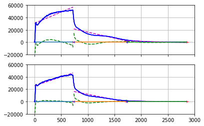

```python
f,(ax1, ax2) = plt.subplots(nrows=2, ncols=1, sharex=True, sharey=True)

for i in intervals:
    ax1.plot(xn2, mitgas, 'b-')
    ax1.plot(np.arange(*i), (yn2-yn2_detrend[1])[np.arange(*i)], 'm--')
    ax1.plot(np.arange(*i), yn2_detrend[1][np.arange(*i)], 'g--')
    ax1.plot(np.arange(*i), [0 for j in np.arange(*i)])
    ax1.plot(i[0],0, 'b3', markersize=5)
    ax1.plot(i[1],0, 'r4', markersize=5)

    ax2.plot(xno, nogas, 'b-')
    ax2.plot(np.arange(*i), (yno-yno_detrend[1])[np.arange(*i)], 'm--')
    ax2.plot(np.arange(*i), yno_detrend[1][np.arange(*i)], 'g--')
    ax2.plot(np.arange(*i), [0 for j in np.arange(*i)])
    ax2.plot(i[0],0, 'b3', markersize=5)
    ax2.plot(i[1],0, 'r4', markersize=5)
plt.ylim(-20000,60000)
ax1.grid()
ax2.grid()
plt.show()
```

```python
im2.getIntervals()
```

```
[{'length': 723, 'start': 0},
 {'length': 999, 'start': 737},
 {'length': 1120, 'start': 1736}]
```

### Demonstrate waveform segmentation and aggregation on one waveform

Acquire one wave...

```python
sg = segmenter.Segmenter(im2.getIntervals())
sg.getSegments()
wave = data[0:1]["waveforms"].values[0]
```

...segment it and plot the segments...

```
segments: [(0, 723), (737, 1736), (1736, 2856)]
number of segments: 3
number of wavesets: 3
```

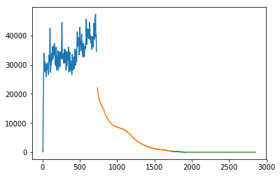

```python
segs =  sg.getSegments()

wavesets = sg.sliceWave(segs, wave)
logger.info( "segments: {}".format(segs))
logger.info( "number of segments: " + str(len(segs)) )
logger.info( "number of wavesets: " + str(len(wavesets)) )
sg.plotSegs(segs, wavesets)
```

...finally, instantiate an Aggregator and compute the aggregate values.

```python
ag = aggregator.Aggregator(nfft=0)

ts_features = []
for w in wavesets:
    ag.setWavelet(w)
    ts_features.append(ag.getFeatures())
ts_features
```

```
wavelet length: 723
wavelet length: 999
wavelet length: 1120
```

```
[{'max': 47354,
  'mean': 33829.525587828495,
  'min': 104,
  'slope': 18.138182637260599,
  'var': 850293608831.50244},
 {'max': 22108,
  'mean': 5830.5025025025025,
  'min': 301,
  'slope': -16.548336288191987,
  'var': 59351136838.568314},
 {'max': 353,
  'mean': 24.495535714285715,
  'min': 0,
  'slope': -0.11708819323038359,
  'var': 5618658.9687300697}]
```